# Biosecurity Alert

New records listing potential invasive species have been submitted to the ALA. All new observations are listed in the table below. Click on the species name to view the record, on the map/coordinates to view location via Google Maps, or on an image to link to a full-size version. Links will open in your default browser.

Species

Observation

Location

Image

[*Chlamydera nuchalis*](https://biocache.ala.org.au/occurrences/c69ddb5f-d9ed-446f-9145-9190729563b1)  
Supplied as:  
*Chlamydera nuchalis*  
Common name:  
Great Bowerbird

**Romain SOUCHAUD**  
20:46 06-02-2024  
TOWNSVILLE CITY  
QLD  
([146.743358, -19.322367](https://www.google.com/maps/search/?api=1&query=-19.322367%2C146.743358))  
*iNaturalist Australia*

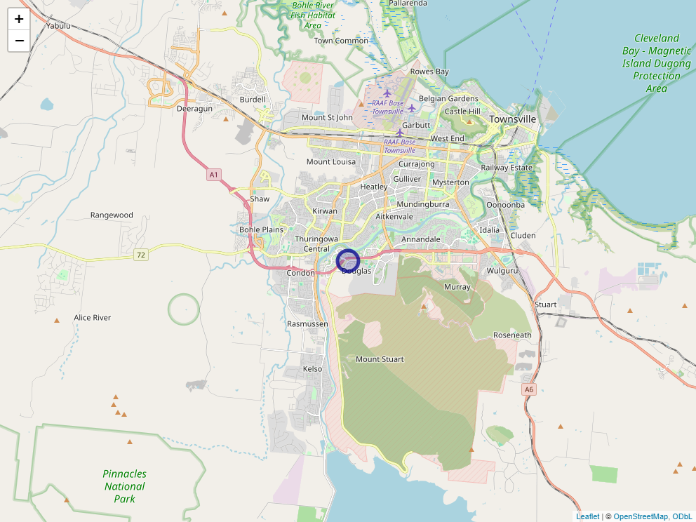

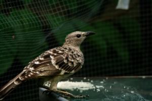

[*Aviceda (Aviceda) subcristata*](https://biocache.ala.org.au/occurrences/19f6a1e2-096b-484d-817d-2476afda80d5)  
Supplied as:  
*Aviceda (Aviceda) subcristata*  
Common name:  
Pacific Baza

**Rosario**  
00:36 08-02-2024  
D'Aguilar NP  
BRISBANE CITY  
QLD  
([152.903115, -27.423618](https://www.google.com/maps/search/?api=1&query=-27.423618%2C152.903115))  
*iNaturalist Australia*

[figure not shown]

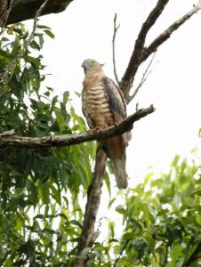

[*Ceyx azureus*](https://biocache.ala.org.au/occurrences/64e1e25f-86fb-465a-a425-7e6c8f15bcf2)  
Supplied as:  
*Ceyx azureus*  
Common name:  
Azure Kingfisher

**enmotoinsects**  
04:06 11-02-2024  
CASSOWARY COAST REGIONAL  
QLD  
([146.032153, -17.474502](https://www.google.com/maps/search/?api=1&query=-17.474502%2C146.032153))  
*iNaturalist Australia*

[figure not shown]

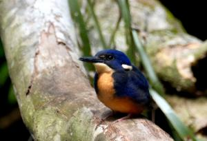

[*Chlamydera nuchalis*](https://biocache.ala.org.au/occurrences/7a43c18d-e182-4bd2-b314-4c5595ac3162)  
Supplied as:  
*Chlamydera nuchalis*  
Common name:  
Great Bowerbird

**Sam Shephard**  
00:00 15-02-2024  
TOWNSVILLE CITY  
QLD  
([146.751283, -19.324129](https://www.google.com/maps/search/?api=1&query=-19.324129%2C146.751283))  
*iNaturalist Australia*

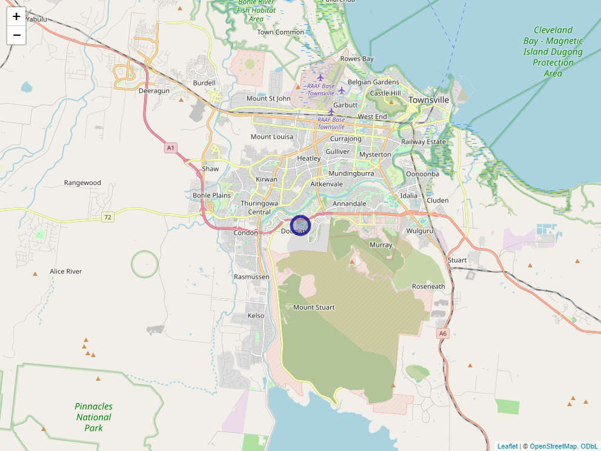

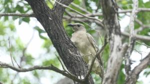

[*Parvipsitta porphyrocephala*](https://biocache.ala.org.au/occurrences/a33c18e3-73f2-4781-81f1-9389b1ce705d)  
Supplied as:  
*Parvipsitta porphyrocephala*  
Common name:  
Purple-Crowned Lorikeet

**Kerry + Darren**  
00:04 17-02-2024  
SHIRE OF PLANTAGENET  
WA  
([117.70196, -34.773647](https://www.google.com/maps/search/?api=1&query=-34.773647%2C117.70196))  
*iNaturalist Australia*

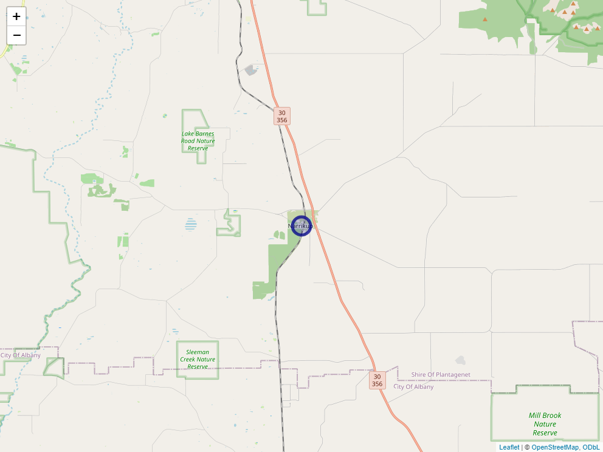

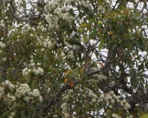

**List**

This email was generated by the ALA using R at 14:29 (ACDT) on Friday, 23 February 2024.

If you notice a record has been misidentified, we encourage you to use your expertise to improve the quality of Australia’s biosecurity data. Please either annotate the record in the provider platform itself or notify us at biosecurity@ala.org.au and we can make the suggested change.

**The ALA is made possible by contributions from its partners, is supported by [NCRIS](https://www.education.gov.au/national-collaborative-research-infrastructure-strategy-ncris), is hosted by [CSIRO](https://csiro.au/), and is the Australian node of [GBIF](https://www.gbif.org/en/).**

[figure not shown]

#### Acknowledgement of Traditional Owners and Country The Atlas of Living Australia acknowledges Australia’s Traditional Owners and pays respect to the past and present Elders of the nation’s Aboriginal and Torres Strait Islander communities. We honour and celebrate the spiritual, cultural and customary connections of Traditional Owners to country and the biodiversity that forms part of that country.